# Risk Factor Analysis

## Outcome Variable

**Outcome Variable:** stunted

## Predictor Variables

**Intervention Variable:** hhwealth_quart

**Adjustment Set:**

unadjusted

## Stratifying Variables

The analysis was stratified on these variable(s):

- agecat
- studyid
- country

## Data Summary

| agecat | studyid | country | hhwealth_quart | stunted | n_cell | n | outcome_variable |
| --- | --- | --- | --- | --- | --- | --- | --- |
| Birth | ki0047075b-MAL-ED | BANGLADESH | Wealth Q4 | 0 | 51 | 213 | stunted |
| Birth | ki0047075b-MAL-ED | BANGLADESH | Wealth Q4 | 1 | 5 | 213 | stunted |
| Birth | ki0047075b-MAL-ED | BANGLADESH | Wealth Q1 | 0 | 41 | 213 | stunted |
| Birth | ki0047075b-MAL-ED | BANGLADESH | Wealth Q1 | 1 | 11 | 213 | stunted |
| Birth | ki0047075b-MAL-ED | BANGLADESH | Wealth Q2 | 0 | 39 | 213 | stunted |
| Birth | ki0047075b-MAL-ED | BANGLADESH | Wealth Q2 | 1 | 12 | 213 | stunted |
| Birth | ki0047075b-MAL-ED | BANGLADESH | Wealth Q3 | 0 | 45 | 213 | stunted |
| Birth | ki0047075b-MAL-ED | BANGLADESH | Wealth Q3 | 1 | 9 | 213 | stunted |
| Birth | ki0047075b-MAL-ED | BRAZIL | Wealth Q4 | 0 | 9 | 60 | stunted |
| Birth | ki0047075b-MAL-ED | BRAZIL | Wealth Q4 | 1 | 2 | 60 | stunted |
| Birth | ki0047075b-MAL-ED | BRAZIL | Wealth Q1 | 0 | 17 | 60 | stunted |
| Birth | ki0047075b-MAL-ED | BRAZIL | Wealth Q1 | 1 | 4 | 60 | stunted |
| Birth | ki0047075b-MAL-ED | BRAZIL | Wealth Q2 | 0 | 16 | 60 | stunted |
| Birth | ki0047075b-MAL-ED | BRAZIL | Wealth Q2 | 1 | 1 | 60 | stunted |
| Birth | ki0047075b-MAL-ED | BRAZIL | Wealth Q3 | 0 | 9 | 60 | stunted |
| Birth | ki0047075b-MAL-ED | BRAZIL | Wealth Q3 | 1 | 2 | 60 | stunted |
| Birth | ki0047075b-MAL-ED | INDIA | Wealth Q4 | 0 | 8 | 41 | stunted |
| Birth | ki0047075b-MAL-ED | INDIA | Wealth Q4 | 1 | 0 | 41 | stunted |
| Birth | ki0047075b-MAL-ED | INDIA | Wealth Q1 | 0 | 10 | 41 | stunted |
| Birth | ki0047075b-MAL-ED | INDIA | Wealth Q1 | 1 | 4 | 41 | stunted |
| Birth | ki0047075b-MAL-ED | INDIA | Wealth Q2 | 0 | 6 | 41 | stunted |
| Birth | ki0047075b-MAL-ED | INDIA | Wealth Q2 | 1 | 3 | 41 | stunted |
| Birth | ki0047075b-MAL-ED | INDIA | Wealth Q3 | 0 | 9 | 41 | stunted |
| Birth | ki0047075b-MAL-ED | INDIA | Wealth Q3 | 1 | 1 | 41 | stunted |
| Birth | ki0047075b-MAL-ED | NEPAL | Wealth Q4 | 0 | 6 | 26 | stunted |
| Birth | ki0047075b-MAL-ED | NEPAL | Wealth Q4 | 1 | 0 | 26 | stunted |
| Birth | ki0047075b-MAL-ED | NEPAL | Wealth Q1 | 0 | 8 | 26 | stunted |
| Birth | ki0047075b-MAL-ED | NEPAL | Wealth Q1 | 1 | 1 | 26 | stunted |
| Birth | ki0047075b-MAL-ED | NEPAL | Wealth Q2 | 0 | 2 | 26 | stunted |
| Birth | ki0047075b-MAL-ED | NEPAL | Wealth Q2 | 1 | 1 | 26 | stunted |

[output cut: 386 more lines]

The following strata were considered:

- agecat: 24 months, studyid: ki0047075b-MAL-ED, country: BANGLADESH
- agecat: 24 months, studyid: ki0047075b-MAL-ED, country: BRAZIL
- agecat: 24 months, studyid: ki0047075b-MAL-ED, country: INDIA
- agecat: 24 months, studyid: ki0047075b-MAL-ED, country: NEPAL
- agecat: 24 months, studyid: ki0047075b-MAL-ED, country: PERU
- agecat: 24 months, studyid: ki0047075b-MAL-ED, country: SOUTH AFRICA
- agecat: 24 months, studyid: ki0047075b-MAL-ED, country: TANZANIA, UNITED REPUBLIC OF
- agecat: 24 months, studyid: ki1000108-CMC-V-BCS-2002, country: INDIA
- agecat: 24 months, studyid: ki1000108-IRC, country: INDIA
- agecat: 24 months, studyid: ki1017093b-PROVIDE, country: BANGLADESH
- agecat: 24 months, studyid: ki1066203-TanzaniaChild2, country: TANZANIA, UNITED REPUBLIC OF
- agecat: 24 months, studyid: ki1113344-GMS-Nepal, country: NEPAL
- agecat: 24 months, studyid: ki1114097-CONTENT, country: PERU
- agecat: 24 months, studyid: ki1135781-COHORTS, country: GUATEMALA
- agecat: 24 months, studyid: ki1135781-COHORTS, country: PHILIPPINES
- agecat: 24 months, studyid: ki1148112-LCNI-5, country: MALAWI
- agecat: 24 months, studyid: kiGH5241-JiVitA-3, country: BANGLADESH
- agecat: 24 months, studyid: kiGH5241-JiVitA-4, country: BANGLADESH
- agecat: 6 months, studyid: ki0047075b-MAL-ED, country: BANGLADESH
- agecat: 6 months, studyid: ki0047075b-MAL-ED, country: BRAZIL
- agecat: 6 months, studyid: ki0047075b-MAL-ED, country: INDIA
- agecat: 6 months, studyid: ki0047075b-MAL-ED, country: NEPAL
- agecat: 6 months, studyid: ki0047075b-MAL-ED, country: PERU
- agecat: 6 months, studyid: ki0047075b-MAL-ED, country: SOUTH AFRICA
- agecat: 6 months, studyid: ki0047075b-MAL-ED, country: TANZANIA, UNITED REPUBLIC OF
- agecat: 6 months, studyid: ki1000108-CMC-V-BCS-2002, country: INDIA
- agecat: 6 months, studyid: ki1000108-IRC, country: INDIA
- agecat: 6 months, studyid: ki1017093b-PROVIDE, country: BANGLADESH
- agecat: 6 months, studyid: ki1066203-TanzaniaChild2, country: TANZANIA, UNITED REPUBLIC OF
- agecat: 6 months, studyid: ki1113344-GMS-Nepal, country: NEPAL
- agecat: 6 months, studyid: ki1114097-CONTENT, country: PERU
- agecat: 6 months, studyid: ki1135781-COHORTS, country: GUATEMALA
- agecat: 6 months, studyid: ki1135781-COHORTS, country: PHILIPPINES
- agecat: 6 months, studyid: ki1148112-LCNI-5, country: MALAWI
- agecat: 6 months, studyid: kiGH5241-JiVitA-3, country: BANGLADESH
- agecat: 6 months, studyid: kiGH5241-JiVitA-4, country: BANGLADESH
- agecat: Birth, studyid: ki0047075b-MAL-ED, country: BANGLADESH
- agecat: Birth, studyid: ki0047075b-MAL-ED, country: BRAZIL
- agecat: Birth, studyid: ki0047075b-MAL-ED, country: INDIA
- agecat: Birth, studyid: ki0047075b-MAL-ED, country: NEPAL
- agecat: Birth, studyid: ki0047075b-MAL-ED, country: PERU
- agecat: Birth, studyid: ki0047075b-MAL-ED, country: SOUTH AFRICA
- agecat: Birth, studyid: ki0047075b-MAL-ED, country: TANZANIA, UNITED REPUBLIC OF
- agecat: Birth, studyid: ki1000108-CMC-V-BCS-2002, country: INDIA
- agecat: Birth, studyid: ki1000108-IRC, country: INDIA
- agecat: Birth, studyid: ki1017093b-PROVIDE, country: BANGLADESH
- agecat: Birth, studyid: ki1113344-GMS-Nepal, country: NEPAL
- agecat: Birth, studyid: ki1114097-CONTENT, country: PERU
- agecat: Birth, studyid: ki1135781-COHORTS, country: GUATEMALA
- agecat: Birth, studyid: ki1135781-COHORTS, country: PHILIPPINES
- agecat: Birth, studyid: kiGH5241-JiVitA-3, country: BANGLADESH
- agecat: Birth, studyid: kiGH5241-JiVitA-4, country: BANGLADESH

### Dropped Strata

Some strata were dropped due to rare outcomes:

- agecat: Birth, studyid: ki0047075b-MAL-ED, country: BRAZIL
- agecat: Birth, studyid: ki0047075b-MAL-ED, country: INDIA
- agecat: Birth, studyid: ki0047075b-MAL-ED, country: NEPAL
- agecat: Birth, studyid: ki0047075b-MAL-ED, country: SOUTH AFRICA
- agecat: Birth, studyid: ki0047075b-MAL-ED, country: TANZANIA, UNITED REPUBLIC OF
- agecat: Birth, studyid: ki1000108-CMC-V-BCS-2002, country: INDIA
- agecat: Birth, studyid: ki1017093b-PROVIDE, country: BANGLADESH
- agecat: Birth, studyid: ki1114097-CONTENT, country: PERU
- agecat: 6 months, studyid: ki0047075b-MAL-ED, country: BRAZIL
- agecat: 6 months, studyid: ki0047075b-MAL-ED, country: NEPAL
- agecat: 6 months, studyid: ki1114097-CONTENT, country: PERU
- agecat: 24 months, studyid: ki0047075b-MAL-ED, country: BRAZIL
- agecat: 24 months, studyid: ki1066203-TanzaniaChild2, country: TANZANIA, UNITED REPUBLIC OF
- agecat: 24 months, studyid: ki1114097-CONTENT, country: PERU

## Methods Detail

We’re interested in the causal parameters $E[Y_a]$ for all values of $a \in \mathcal{A}$. These parameters represent the mean outcome if, possibly contrary to fact, we intervened to set all units to have $A=a$. Under the randomization and positivity assumptions, these are identified by the statistical parameters $\psi_a=E_W[E_{Y|A,W}(Y|A=a,W)]$. In addition, we’re interested in the mean of $Y$, $E[Y]$ under no intervention (the observed mean). We will estimate these parameters by using SuperLearner to fit the relevant likelihood factors – $E_{Y|A,W}(Y|A=a,W)$ and $p(A=a|W)$, and then updating our likelihood fit using a joint TMLE.

For unadjusted analyses ($W=\{\}$), initial likelihoods were estimated using Lrnr_glm to estimate the simple $E(Y|A)$ and Lrnr_mean to estimate $p(A)$. For adjusted analyses, a small library containing Lrnr_glmnet, Lrnr_xgboost, and Lrnr_mean was used.

Having estimated these parameters, we will then use the delta method to estimate relative risks and attributable risks relative to a prespecified baseline level of $A$.

# Results Detail

## Results Plots

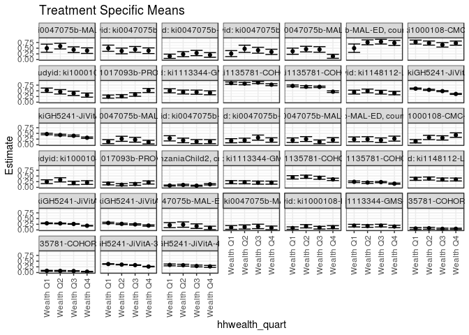

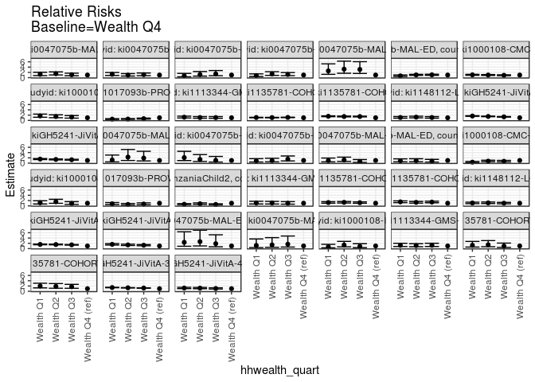

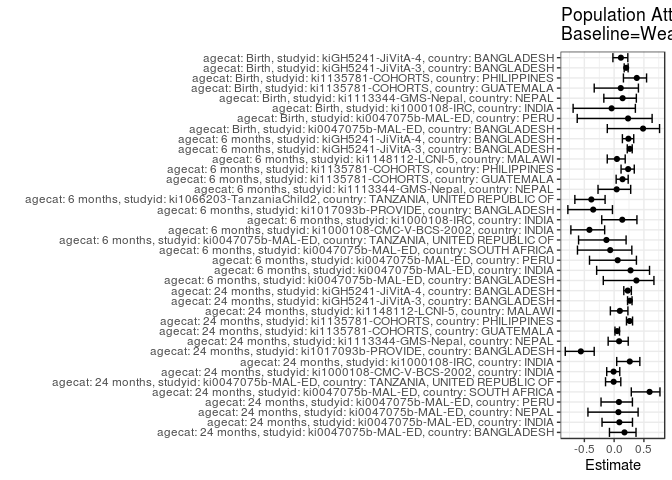

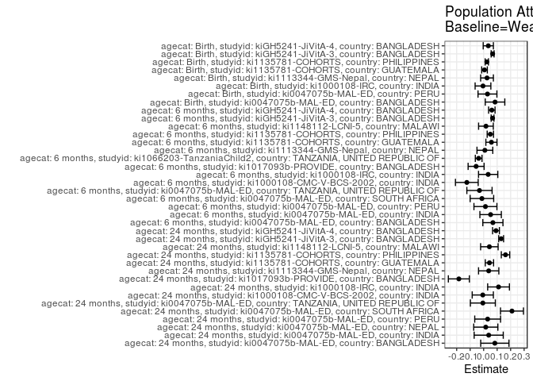

## Results Table

### Parameter: TSM

| agecat | studyid | country | intervention_level | baseline_level | estimate | ci_lower | ci_upper |
| --- | --- | --- | --- | --- | --- | --- | --- |
| Birth | ki0047075b-MAL-ED | BANGLADESH | Wealth Q4 | NA | 0.0892857 | 0.0144243 | 0.1641471 |
| Birth | ki0047075b-MAL-ED | BANGLADESH | Wealth Q1 | NA | 0.2115385 | 0.1002748 | 0.3228021 |
| Birth | ki0047075b-MAL-ED | BANGLADESH | Wealth Q2 | NA | 0.2352941 | 0.1186030 | 0.3519852 |
| Birth | ki0047075b-MAL-ED | BANGLADESH | Wealth Q3 | NA | 0.1666667 | 0.0670328 | 0.2663005 |
| Birth | ki0047075b-MAL-ED | PERU | Wealth Q4 | NA | 0.0925926 | 0.0151013 | 0.1700839 |
| Birth | ki0047075b-MAL-ED | PERU | Wealth Q1 | NA | 0.1090909 | 0.0265080 | 0.1916738 |
| Birth | ki0047075b-MAL-ED | PERU | Wealth Q2 | NA | 0.1296296 | 0.0398314 | 0.2194279 |
| Birth | ki0047075b-MAL-ED | PERU | Wealth Q3 | NA | 0.1538462 | 0.0555522 | 0.2521401 |
| Birth | ki1000108-IRC | INDIA | Wealth Q4 | NA | 0.1208791 | 0.0538154 | 0.1879429 |
| Birth | ki1000108-IRC | INDIA | Wealth Q1 | NA | 0.0816327 | 0.0273532 | 0.1359121 |
| Birth | ki1000108-IRC | INDIA | Wealth Q2 | NA | 0.1616162 | 0.0890131 | 0.2342192 |
| Birth | ki1000108-IRC | INDIA | Wealth Q3 | NA | 0.1000000 | 0.0411252 | 0.1588748 |
| Birth | ki1113344-GMS-Nepal | NEPAL | Wealth Q4 | NA | 0.1502890 | 0.0970001 | 0.2035779 |
| Birth | ki1113344-GMS-Nepal | NEPAL | Wealth Q1 | NA | 0.1885714 | 0.1305746 | 0.2465683 |
| Birth | ki1113344-GMS-Nepal | NEPAL | Wealth Q2 | NA | 0.1724138 | 0.1162472 | 0.2285804 |
| Birth | ki1113344-GMS-Nepal | NEPAL | Wealth Q3 | NA | 0.1896552 | 0.1313640 | 0.2479464 |
| Birth | ki1135781-COHORTS | GUATEMALA | Wealth Q4 | NA | 0.0511945 | 0.0259434 | 0.0764457 |
| Birth | ki1135781-COHORTS | GUATEMALA | Wealth Q1 | NA | 0.0636943 | 0.0254714 | 0.1019172 |
| Birth | ki1135781-COHORTS | GUATEMALA | Wealth Q2 | NA | 0.0745342 | 0.0339404 | 0.1151279 |
| Birth | ki1135781-COHORTS | GUATEMALA | Wealth Q3 | NA | 0.0487805 | 0.0192751 | 0.0782858 |
| Birth | ki1135781-COHORTS | PHILIPPINES | Wealth Q4 | NA | 0.0380048 | 0.0250875 | 0.0509220 |
| Birth | ki1135781-COHORTS | PHILIPPINES | Wealth Q1 | NA | 0.0756914 | 0.0559093 | 0.0954735 |
| Birth | ki1135781-COHORTS | PHILIPPINES | Wealth Q2 | NA | 0.0706320 | 0.0489787 | 0.0922852 |
| Birth | ki1135781-COHORTS | PHILIPPINES | Wealth Q3 | NA | 0.0661914 | 0.0506392 | 0.0817437 |
| Birth | kiGH5241-JiVitA-3 | BANGLADESH | Wealth Q4 | NA | 0.2624100 | 0.2496393 | 0.2751807 |
| Birth | kiGH5241-JiVitA-3 | BANGLADESH | Wealth Q1 | NA | 0.3738739 | 0.3605802 | 0.3871676 |
| Birth | kiGH5241-JiVitA-3 | BANGLADESH | Wealth Q2 | NA | 0.3485353 | 0.3349256 | 0.3621451 |
| Birth | kiGH5241-JiVitA-3 | BANGLADESH | Wealth Q3 | NA | 0.3260602 | 0.3135029 | 0.3386175 |
| Birth | kiGH5241-JiVitA-4 | BANGLADESH | Wealth Q4 | NA | 0.2691131 | 0.2261807 | 0.3120456 |
| Birth | kiGH5241-JiVitA-4 | BANGLADESH | Wealth Q1 | NA | 0.3343066 | 0.2957915 | 0.3728216 |

[output cut: 122 more lines]

### Parameter: E(Y)

| agecat | studyid | country | intervention_level | baseline_level | estimate | ci_lower | ci_upper |
| --- | --- | --- | --- | --- | --- | --- | --- |
| Birth | ki0047075b-MAL-ED | BANGLADESH | NA | NA | 0.1737089 | 0.1227104 | 0.2247075 |
| Birth | ki0047075b-MAL-ED | PERU | NA | NA | 0.1209302 | 0.0772464 | 0.1646140 |
| Birth | ki1000108-IRC | INDIA | NA | NA | 0.1159794 | 0.0840777 | 0.1478811 |
| Birth | ki1113344-GMS-Nepal | NEPAL | NA | NA | 0.1752874 | 0.1470202 | 0.2035545 |
| Birth | ki1135781-COHORTS | GUATEMALA | NA | NA | 0.0575980 | 0.0416028 | 0.0735933 |
| Birth | ki1135781-COHORTS | PHILIPPINES | NA | NA | 0.0613316 | 0.0528136 | 0.0698496 |
| Birth | kiGH5241-JiVitA-3 | BANGLADESH | NA | NA | 0.3290987 | 0.3217223 | 0.3364751 |
| Birth | kiGH5241-JiVitA-4 | BANGLADESH | NA | NA | 0.3035461 | 0.2835868 | 0.3235054 |
| 6 months | ki0047075b-MAL-ED | BANGLADESH | NA | NA | 0.1833333 | 0.1342773 | 0.2323893 |
| 6 months | ki0047075b-MAL-ED | INDIA | NA | NA | 0.1872340 | 0.1372518 | 0.2372162 |
| 6 months | ki0047075b-MAL-ED | PERU | NA | NA | 0.2222222 | 0.1725409 | 0.2719036 |
| 6 months | ki0047075b-MAL-ED | SOUTH AFRICA | NA | NA | 0.1967871 | 0.1473064 | 0.2462679 |
| 6 months | ki0047075b-MAL-ED | TANZANIA, UNITED REPUBLIC OF | NA | NA | 0.2388664 | 0.1855834 | 0.2921494 |
| 6 months | ki1000108-CMC-V-BCS-2002 | INDIA | NA | NA | 0.3008130 | 0.2539566 | 0.3476694 |
| 6 months | ki1000108-IRC | INDIA | NA | NA | 0.2457002 | 0.2038248 | 0.2875757 |
| 6 months | ki1017093b-PROVIDE | BANGLADESH | NA | NA | 0.1589404 | 0.1297581 | 0.1881227 |
| 6 months | ki1066203-TanzaniaChild2 | TANZANIA, UNITED REPUBLIC OF | NA | NA | 0.0965347 | 0.0836528 | 0.1094165 |
| 6 months | ki1113344-GMS-Nepal | NEPAL | NA | NA | 0.2163121 | 0.1823021 | 0.2503220 |
| 6 months | ki1135781-COHORTS | GUATEMALA | NA | NA | 0.4086486 | 0.3769522 | 0.4403450 |
| 6 months | ki1135781-COHORTS | PHILIPPINES | NA | NA | 0.2112260 | 0.1958496 | 0.2266024 |
| 6 months | ki1148112-LCNI-5 | MALAWI | NA | NA | 0.3627451 | 0.3297365 | 0.3957537 |
| 6 months | kiGH5241-JiVitA-3 | BANGLADESH | NA | NA | 0.2513837 | 0.2432545 | 0.2595129 |
| 6 months | kiGH5241-JiVitA-4 | BANGLADESH | NA | NA | 0.2524352 | 0.2383740 | 0.2664965 |
| 24 months | ki0047075b-MAL-ED | BANGLADESH | NA | NA | 0.4764151 | 0.4090254 | 0.5438047 |
| 24 months | ki0047075b-MAL-ED | INDIA | NA | NA | 0.4273128 | 0.3628178 | 0.4918077 |
| 24 months | ki0047075b-MAL-ED | NEPAL | NA | NA | 0.2192982 | 0.1654718 | 0.2731246 |
| 24 months | ki0047075b-MAL-ED | PERU | NA | NA | 0.3681592 | 0.3013164 | 0.4350020 |
| 24 months | ki0047075b-MAL-ED | SOUTH AFRICA | NA | NA | 0.3529412 | 0.2921001 | 0.4137823 |
| 24 months | ki0047075b-MAL-ED | TANZANIA, UNITED REPUBLIC OF | NA | NA | 0.7242991 | 0.6642873 | 0.7843108 |
| 24 months | ki1000108-CMC-V-BCS-2002 | INDIA | NA | NA | 0.7169811 | 0.6710815 | 0.7628807 |
| 24 months | ki1000108-IRC | INDIA | NA | NA | 0.4205379 | 0.3726382 | 0.4684376 |
| 24 months | ki1017093b-PROVIDE | BANGLADESH | NA | NA | 0.3287197 | 0.2903909 | 0.3670485 |
| 24 months | ki1113344-GMS-Nepal | NEPAL | NA | NA | 0.4487705 | 0.4045970 | 0.4929440 |
| 24 months | ki1135781-COHORTS | GUATEMALA | NA | NA | 0.8115942 | 0.7877598 | 0.8354286 |
| 24 months | ki1135781-COHORTS | PHILIPPINES | NA | NA | 0.6229039 | 0.6036892 | 0.6421186 |
| 24 months | ki1148112-LCNI-5 | MALAWI | NA | NA | 0.4425087 | 0.4018409 | 0.4831765 |
| 24 months | kiGH5241-JiVitA-3 | BANGLADESH | NA | NA | 0.4911284 | 0.4780181 | 0.5042387 |
| 24 months | kiGH5241-JiVitA-4 | BANGLADESH | NA | NA | 0.4008848 | 0.3839144 | 0.4178552 |

### Parameter: RR

| agecat | studyid | country | intervention_level | baseline_level | estimate | ci_lower | ci_upper |
| --- | --- | --- | --- | --- | --- | --- | --- |
| Birth | ki0047075b-MAL-ED | BANGLADESH | Wealth Q4 | Wealth Q4 | 1.0000000 | 1.0000000 | 1.0000000 |
| Birth | ki0047075b-MAL-ED | BANGLADESH | Wealth Q1 | Wealth Q4 | 2.3692305 | 0.8805542 | 6.3746820 |
| Birth | ki0047075b-MAL-ED | BANGLADESH | Wealth Q2 | Wealth Q4 | 2.6352938 | 0.9948682 | 6.9805963 |
| Birth | ki0047075b-MAL-ED | BANGLADESH | Wealth Q3 | Wealth Q4 | 1.8666664 | 0.6665867 | 5.2272925 |
| Birth | ki0047075b-MAL-ED | PERU | Wealth Q4 | Wealth Q4 | 1.0000000 | 1.0000000 | 1.0000000 |
| Birth | ki0047075b-MAL-ED | PERU | Wealth Q1 | Wealth Q4 | 1.1781817 | 0.3811695 | 3.6417193 |
| Birth | ki0047075b-MAL-ED | PERU | Wealth Q2 | Wealth Q4 | 1.3999999 | 0.4723963 | 4.1490582 |
| Birth | ki0047075b-MAL-ED | PERU | Wealth Q3 | Wealth Q4 | 1.6615383 | 0.5797459 | 4.7619308 |
| Birth | ki1000108-IRC | INDIA | Wealth Q4 | Wealth Q4 | 1.0000000 | 1.0000000 | 1.0000000 |
| Birth | ki1000108-IRC | INDIA | Wealth Q1 | Wealth Q4 | 0.6753247 | 0.2840672 | 1.6054774 |
| Birth | ki1000108-IRC | INDIA | Wealth Q2 | Wealth Q4 | 1.3370064 | 0.6547919 | 2.7300066 |
| Birth | ki1000108-IRC | INDIA | Wealth Q3 | Wealth Q4 | 0.8272727 | 0.3683993 | 1.8577130 |
| Birth | ki1113344-GMS-Nepal | NEPAL | Wealth Q4 | Wealth Q4 | 1.0000000 | 1.0000000 | 1.0000000 |
| Birth | ki1113344-GMS-Nepal | NEPAL | Wealth Q1 | Wealth Q4 | 1.2547253 | 0.7846933 | 2.0063069 |
| Birth | ki1113344-GMS-Nepal | NEPAL | Wealth Q2 | Wealth Q4 | 1.1472149 | 0.7088094 | 1.8567784 |
| Birth | ki1113344-GMS-Nepal | NEPAL | Wealth Q3 | Wealth Q4 | 1.2619363 | 0.7893092 | 2.0175658 |
| Birth | ki1135781-COHORTS | GUATEMALA | Wealth Q4 | Wealth Q4 | 1.0000000 | 1.0000000 | 1.0000000 |
| Birth | ki1135781-COHORTS | GUATEMALA | Wealth Q1 | Wealth Q4 | 1.2441614 | 0.5721643 | 2.7054073 |
| Birth | ki1135781-COHORTS | GUATEMALA | Wealth Q2 | Wealth Q4 | 1.4559006 | 0.6982621 | 3.0356032 |
| Birth | ki1135781-COHORTS | GUATEMALA | Wealth Q3 | Wealth Q4 | 0.9528455 | 0.4365830 | 2.0795921 |
| Birth | ki1135781-COHORTS | PHILIPPINES | Wealth Q4 | Wealth Q4 | 1.0000000 | 1.0000000 | 1.0000000 |
| Birth | ki1135781-COHORTS | PHILIPPINES | Wealth Q1 | Wealth Q4 | 1.9916303 | 1.2971947 | 3.0578225 |
| Birth | ki1135781-COHORTS | PHILIPPINES | Wealth Q2 | Wealth Q4 | 1.8585037 | 1.1759273 | 2.9372872 |
| Birth | ki1135781-COHORTS | PHILIPPINES | Wealth Q3 | Wealth Q4 | 1.7416624 | 1.1521723 | 2.6327556 |
| Birth | kiGH5241-JiVitA-3 | BANGLADESH | Wealth Q4 | Wealth Q4 | 1.0000000 | 1.0000000 | 1.0000000 |
| Birth | kiGH5241-JiVitA-3 | BANGLADESH | Wealth Q1 | Wealth Q4 | 1.4247699 | 1.3441694 | 1.5102034 |
| Birth | kiGH5241-JiVitA-3 | BANGLADESH | Wealth Q2 | Wealth Q4 | 1.3282091 | 1.2522455 | 1.4087808 |
| Birth | kiGH5241-JiVitA-3 | BANGLADESH | Wealth Q3 | Wealth Q4 | 1.2425600 | 1.1707367 | 1.3187897 |
| Birth | kiGH5241-JiVitA-4 | BANGLADESH | Wealth Q4 | Wealth Q4 | 1.0000000 | 1.0000000 | 1.0000000 |
| Birth | kiGH5241-JiVitA-4 | BANGLADESH | Wealth Q1 | Wealth Q4 | 1.2422528 | 1.0209748 | 1.5114889 |

[output cut: 122 more lines]

### Parameter: PAR

| agecat | studyid | country | intervention_level | baseline_level | estimate | ci_lower | ci_upper |
| --- | --- | --- | --- | --- | --- | --- | --- |
| Birth | ki0047075b-MAL-ED | BANGLADESH | Wealth Q4 | NA | 0.0844232 | 0.0119094 | 0.1569370 |
| Birth | ki0047075b-MAL-ED | PERU | Wealth Q4 | NA | 0.0283376 | -0.0416392 | 0.0983145 |
| Birth | ki1000108-IRC | INDIA | Wealth Q4 | NA | -0.0048997 | -0.0632572 | 0.0534577 |
| Birth | ki1113344-GMS-Nepal | NEPAL | Wealth Q4 | NA | 0.0249983 | -0.0221932 | 0.0721899 |
| Birth | ki1135781-COHORTS | GUATEMALA | Wealth Q4 | NA | 0.0064035 | -0.0144668 | 0.0272738 |
| Birth | ki1135781-COHORTS | PHILIPPINES | Wealth Q4 | NA | 0.0233268 | 0.0111920 | 0.0354617 |
| Birth | kiGH5241-JiVitA-3 | BANGLADESH | Wealth Q4 | NA | 0.0666887 | 0.0558997 | 0.0774777 |
| Birth | kiGH5241-JiVitA-4 | BANGLADESH | Wealth Q4 | NA | 0.0344329 | -0.0033640 | 0.0722299 |
| 6 months | ki0047075b-MAL-ED | BANGLADESH | Wealth Q4 | NA | 0.0685792 | -0.0060197 | 0.1431782 |
| 6 months | ki0047075b-MAL-ED | INDIA | Wealth Q4 | NA | 0.0516408 | -0.0278191 | 0.1311008 |
| 6 months | ki0047075b-MAL-ED | PERU | Wealth Q4 | NA | 0.0132670 | -0.0719365 | 0.0984705 |
| 6 months | ki0047075b-MAL-ED | SOUTH AFRICA | Wealth Q4 | NA | -0.0128903 | -0.1002026 | 0.0744221 |
| 6 months | ki0047075b-MAL-ED | TANZANIA, UNITED REPUBLIC OF | Wealth Q4 | NA | -0.0309749 | -0.1245073 | 0.0625576 |
| 6 months | ki1000108-CMC-V-BCS-2002 | INDIA | Wealth Q4 | NA | -0.1247189 | -0.2090344 | -0.0404035 |
| 6 months | ki1000108-IRC | INDIA | Wealth Q4 | NA | 0.0335790 | -0.0377782 | 0.1049362 |
| 6 months | ki1017093b-PROVIDE | BANGLADESH | Wealth Q4 | NA | -0.0558744 | -0.1151201 | 0.0033713 |
| 6 months | ki1066203-TanzaniaChild2 | TANZANIA, UNITED REPUBLIC OF | Wealth Q4 | NA | -0.0369315 | -0.0616559 | -0.0122071 |
| 6 months | ki1113344-GMS-Nepal | NEPAL | Wealth Q4 | NA | 0.0091692 | -0.0493962 | 0.0677346 |
| 6 months | ki1135781-COHORTS | GUATEMALA | Wealth Q4 | NA | 0.0576162 | 0.0164491 | 0.0987833 |
| 6 months | ki1135781-COHORTS | PHILIPPINES | Wealth Q4 | NA | 0.0497186 | 0.0262132 | 0.0732240 |
| 6 months | ki1148112-LCNI-5 | MALAWI | Wealth Q4 | NA | 0.0171230 | -0.0373396 | 0.0715855 |
| 6 months | kiGH5241-JiVitA-3 | BANGLADESH | Wealth Q4 | NA | 0.0661911 | 0.0557623 | 0.0766198 |
| 6 months | kiGH5241-JiVitA-4 | BANGLADESH | Wealth Q4 | NA | 0.0606087 | 0.0366901 | 0.0845273 |
| 24 months | ki0047075b-MAL-ED | BANGLADESH | Wealth Q4 | NA | 0.0829725 | -0.0216778 | 0.1876228 |
| 24 months | ki0047075b-MAL-ED | INDIA | Wealth Q4 | NA | 0.0374823 | -0.0703558 | 0.1453203 |
| 24 months | ki0047075b-MAL-ED | NEPAL | Wealth Q4 | NA | 0.0159084 | -0.0735859 | 0.1054027 |
| 24 months | ki0047075b-MAL-ED | PERU | Wealth Q4 | NA | 0.0296977 | -0.0660393 | 0.1254346 |
| 24 months | ki0047075b-MAL-ED | SOUTH AFRICA | Wealth Q4 | NA | 0.2100840 | 0.1250543 | 0.2951138 |
| 24 months | ki0047075b-MAL-ED | TANZANIA, UNITED REPUBLIC OF | Wealth Q4 | NA | -0.0058597 | -0.0984062 | 0.0866869 |
| 24 months | ki1000108-CMC-V-BCS-2002 | INDIA | Wealth Q4 | NA | -0.0064231 | -0.0848519 | 0.0720057 |
| 24 months | ki1000108-IRC | INDIA | Wealth Q4 | NA | 0.1105379 | 0.0298935 | 0.1911823 |
| 24 months | ki1017093b-PROVIDE | BANGLADESH | Wealth Q4 | NA | -0.1836770 | -0.2617032 | -0.1056508 |
| 24 months | ki1113344-GMS-Nepal | NEPAL | Wealth Q4 | NA | 0.0374802 | -0.0376726 | 0.1126329 |
| 24 months | ki1135781-COHORTS | GUATEMALA | Wealth Q4 | NA | 0.0429375 | 0.0121527 | 0.0737222 |
| 24 months | ki1135781-COHORTS | PHILIPPINES | Wealth Q4 | NA | 0.1621481 | 0.1309071 | 0.1933890 |
| 24 months | ki1148112-LCNI-5 | MALAWI | Wealth Q4 | NA | 0.0425087 | -0.0223615 | 0.1073789 |
| 24 months | kiGH5241-JiVitA-3 | BANGLADESH | Wealth Q4 | NA | 0.1297590 | 0.1116534 | 0.1478645 |
| 24 months | kiGH5241-JiVitA-4 | BANGLADESH | Wealth Q4 | NA | 0.0915805 | 0.0663238 | 0.1168372 |

### Parameter: PAF

| agecat | studyid | country | intervention_level | baseline_level | estimate | ci_lower | ci_upper |
| --- | --- | --- | --- | --- | --- | --- | --- |
| Birth | ki0047075b-MAL-ED | BANGLADESH | Wealth Q4 | NA | 0.4860038 | -0.1146422 | 0.7629804 |
| Birth | ki0047075b-MAL-ED | PERU | Wealth Q4 | NA | 0.2343304 | -0.6198530 | 0.6380845 |
| Birth | ki1000108-IRC | INDIA | Wealth Q4 | NA | -0.0422466 | -0.6888711 | 0.3568023 |
| Birth | ki1113344-GMS-Nepal | NEPAL | Wealth Q4 | NA | 0.1426135 | -0.1728188 | 0.3732095 |
| Birth | ki1135781-COHORTS | GUATEMALA | Wealth Q4 | NA | 0.1111757 | -0.3344106 | 0.4079718 |
| Birth | ki1135781-COHORTS | PHILIPPINES | Wealth Q4 | NA | 0.3803397 | 0.1562675 | 0.5449044 |
| Birth | kiGH5241-JiVitA-3 | BANGLADESH | Wealth Q4 | NA | 0.2026404 | 0.1690756 | 0.2348493 |
| Birth | kiGH5241-JiVitA-4 | BANGLADESH | Wealth Q4 | NA | 0.1134357 | -0.0205996 | 0.2298681 |
| 6 months | ki0047075b-MAL-ED | BANGLADESH | Wealth Q4 | NA | 0.3740686 | -0.1820668 | 0.6685550 |
| 6 months | ki0047075b-MAL-ED | INDIA | Wealth Q4 | NA | 0.2758089 | -0.2935764 | 0.5945715 |
| 6 months | ki0047075b-MAL-ED | PERU | Wealth Q4 | NA | 0.0597015 | -0.4135261 | 0.3744995 |
| 6 months | ki0047075b-MAL-ED | SOUTH AFRICA | Wealth Q4 | NA | -0.0655036 | -0.6156269 | 0.2973019 |
| 6 months | ki0047075b-MAL-ED | TANZANIA, UNITED REPUBLIC OF | Wealth Q4 | NA | -0.1296745 | -0.5972356 | 0.2010168 |
| 6 months | ki1000108-CMC-V-BCS-2002 | INDIA | Wealth Q4 | NA | -0.4146061 | -0.7265610 | -0.1590152 |
| 6 months | ki1000108-IRC | INDIA | Wealth Q4 | NA | 0.1366667 | -0.2080049 | 0.3829955 |
| 6 months | ki1017093b-PROVIDE | BANGLADESH | Wealth Q4 | NA | -0.3515432 | -0.7771589 | -0.0278591 |
| 6 months | ki1066203-TanzaniaChild2 | TANZANIA, UNITED REPUBLIC OF | Wealth Q4 | NA | -0.3825723 | -0.6596108 | -0.1517797 |
| 6 months | ki1113344-GMS-Nepal | NEPAL | Wealth Q4 | NA | 0.0423888 | -0.2704557 | 0.2781966 |
| 6 months | ki1135781-COHORTS | GUATEMALA | Wealth Q4 | NA | 0.1409920 | 0.0339826 | 0.2361476 |
| 6 months | ki1135781-COHORTS | PHILIPPINES | Wealth Q4 | NA | 0.2353810 | 0.1164988 | 0.3382667 |
| 6 months | ki1148112-LCNI-5 | MALAWI | Wealth Q4 | NA | 0.0472039 | -0.1154182 | 0.1861165 |
| 6 months | kiGH5241-JiVitA-3 | BANGLADESH | Wealth Q4 | NA | 0.2633069 | 0.2206302 | 0.3036468 |
| 6 months | kiGH5241-JiVitA-4 | BANGLADESH | Wealth Q4 | NA | 0.2400961 | 0.1389192 | 0.3293847 |
| 24 months | ki0047075b-MAL-ED | BANGLADESH | Wealth Q4 | NA | 0.1741600 | -0.0783928 | 0.3675666 |
| 24 months | ki0047075b-MAL-ED | INDIA | Wealth Q4 | NA | 0.0877162 | -0.2031720 | 0.3082770 |
| 24 months | ki0047075b-MAL-ED | NEPAL | Wealth Q4 | NA | 0.0725424 | -0.4398007 | 0.4025717 |
| 24 months | ki0047075b-MAL-ED | PERU | Wealth Q4 | NA | 0.0806653 | -0.2199210 | 0.3071876 |
| 24 months | ki0047075b-MAL-ED | SOUTH AFRICA | Wealth Q4 | NA | 0.5952381 | 0.2883722 | 0.7697783 |
| 24 months | ki0047075b-MAL-ED | TANZANIA, UNITED REPUBLIC OF | Wealth Q4 | NA | -0.0080901 | -0.1443235 | 0.1119245 |
| 24 months | ki1000108-CMC-V-BCS-2002 | INDIA | Wealth Q4 | NA | -0.0089586 | -0.1245030 | 0.0947135 |
| 24 months | ki1000108-IRC | INDIA | Wealth Q4 | NA | 0.2628488 | 0.0436175 | 0.4318258 |
| 24 months | ki1017093b-PROVIDE | BANGLADESH | Wealth Q4 | NA | -0.5587647 | -0.8205926 | -0.3345914 |
| 24 months | ki1113344-GMS-Nepal | NEPAL | Wealth Q4 | NA | 0.0835175 | -0.1003413 | 0.2366548 |
| 24 months | ki1135781-COHORTS | GUATEMALA | Wealth Q4 | NA | 0.0529051 | 0.0139676 | 0.0903050 |
| 24 months | ki1135781-COHORTS | PHILIPPINES | Wealth Q4 | NA | 0.2603099 | 0.2074321 | 0.3096599 |
| 24 months | ki1148112-LCNI-5 | MALAWI | Wealth Q4 | NA | 0.0960630 | -0.0632260 | 0.2314878 |
| 24 months | kiGH5241-JiVitA-3 | BANGLADESH | Wealth Q4 | NA | 0.2642058 | 0.2256640 | 0.3008292 |
| 24 months | kiGH5241-JiVitA-4 | BANGLADESH | Wealth Q4 | NA | 0.2284459 | 0.1622812 | 0.2893848 |